# HomeWork5

I. The goal of this problem is to simulate a Geometric ran-dom variable. Assume in a computer game Stardew Val-ley, there is a 10% chance it rains on any given day.

1. Use R to simulate generating days up to and includ-ing the ﬁrst time it rains. Return based on one (ran-dom) run of your simulation the number of days it took up to and including the ﬁrst rainy day.

```
## [1] 1
```

2. Repeat (a) 20000 times, so that you should have 20000 values of how many days it took up to and including the ﬁrst rainy day. Do not print out these values!!! Plot a histogram of these values.

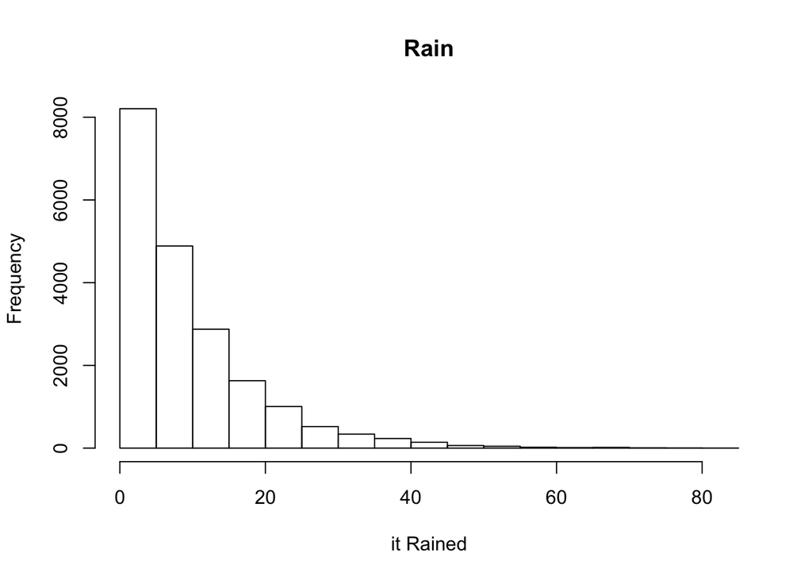

3. What can you say about the distribution of this particular Geometric random variable based on (b)? Describe it.

Answer: The distribution shows that as we get more days where it rains the frequency decreses.

4. Find the expected value and standard deviation of your vector in (b).

```
## [1] 9.96165
```

```
## [1] 9.484597
```

5. Find the probability that it took 15 days until the ﬁrst rainy day.

```
## [1] 0.02275
```

6. Find the probability that if it took more than 10 days, it would take an additional 5 days to observe the ﬁrst rainy day.

```
## [1] 0.002171395
```

2. The goal of this problem is to simulate a Negative Bi-nomial random variable. Consider that 40% of people wear glasses for near-sightedness.
1. Use R to simulate selecting random people until 5 are selected wear glasses. Return one the number of people it took until 5 wore glasses.

```
## [1] 9
```

2. Repeat (a) 20000 times, so that you should have 20000 values of how many people were were selected until 5 wore glasses. Do not print out these val-ues!!! Plot a histogram of these values.